# R Notebook

> Table of Contents: Introduction to Business Problem Task 1: Target Variable Task 2: Relationship Between Target & Predictors Task 3: Missing Data Task 4: Data Transformation Task 5: Transactional Data Task 6: Predicting Default Summary

> Introduction to Business Problem: A majority of the loan applications are rejected because of insufficient or non-existent credit histories of the applicant, who are forced to turn to untrustworthy lenders for their financial needs. To address this issue, Home Credit uses telco and transactional data to predict the loan repayment abilities. If an applicant is deemed fit and capable to repay a loan, their application is accepted or otherwise rejected. Our analytics approach would be to use the full potential of the alternative data to see whether or not an applicant will be able to pay back a loan. Home Credit wants to empower customers by enabling them to borrow easily and safely. With a solution, the business will have an increase in client’s and in turn provide more revenue for Home Credit. The scope of the project is to identify the potential defaulters based on exploratory data analysis with the data given about the applicants features. Our project goal is to find the model with the highest accuracy to deem the the default probability for a specific loan.Success metrics will be defined by a larger circle of prospective clients being accepted that are capable of making loan repayments.

> Task 1: Target Variable Exploration

```r
library(tidyverse)
```

```r
library(ggplot2)
library(caret)
library(e1071)
#library(knitr)
setwd("~/IS-6812")
test <- read.csv(file = "application_test.csv", stringsAsFactors = TRUE)
train <- read.csv(file = "application_train.csv", stringsAsFactors = TRUE)
train <- train %>%
  na.omit(train)
test <- test %>%
  na.omit(test)

str(train)
```

```
## 'data.frame':    11351 obs. of  122 variables:
##  $ SK_ID_CURR                  : int  100083 100145 100165 100179 100190 100193 100289 100295 100341 100343 ...
##  $ TARGET                      : int  0 0 0 0 0 0 0 1 0 0 ...
##  $ NAME_CONTRACT_TYPE          : Factor w/ 2 levels "Cash loans","Revolving loans": 1 1 1 1 1 1 1 1 1 1 ...
##  $ CODE_GENDER                 : Factor w/ 3 levels "F","M","XNA": 2 1 1 1 2 1 2 2 2 2 ...
##  $ FLAG_OWN_CAR                : Factor w/ 2 levels "N","Y": 2 2 2 2 2 2 2 2 2 2 ...
##  $ FLAG_OWN_REALTY             : Factor w/ 2 levels "N","Y": 2 2 2 1 1 1 1 1 2 2 ...
##  $ CNT_CHILDREN                : int  0 1 0 0 0 0 0 1 0 0 ...
##  $ AMT_INCOME_TOTAL            : num  103500 202500 175500 202500 162000 ...
##  $ AMT_CREDIT                  : num  573628 260726 1293502 675000 263686 ...
##  $ AMT_ANNUITY                 : num  24435 16790 35568 53330 24782 ...
##  $ AMT_GOODS_PRICE             : num  463500 198000 1129500 675000 238500 ...
##  $ NAME_TYPE_SUITE             : Factor w/ 8 levels "","Children",..: 8 3 3 8 8 8 8 8 8 8 ...
##  $ NAME_INCOME_TYPE            : Factor w/ 8 levels "Businessman",..: 8 8 4 2 2 2 8 2 8 8 ...
##  $ NAME_EDUCATION_TYPE         : Factor w/ 5 levels "Academic degree",..: 5 5 5 2 2 5 2 5 5 5 ...
```

[output cut: 88 more lines]

```r
summary(train)
```

```
##    SK_ID_CURR         TARGET              NAME_CONTRACT_TYPE CODE_GENDER
##  Min.   :100083   Min.   :0.00000   Cash loans     :10142    F  :5733
##  1st Qu.:189234   1st Qu.:0.00000   Revolving loans: 1209    M  :5617
##  Median :278894   Median :0.00000                            XNA:   1
##  Mean   :278893   Mean   :0.06035
##  3rd Qu.:369246   3rd Qu.:0.00000
##  Max.   :456226   Max.   :1.00000
##
##  FLAG_OWN_CAR FLAG_OWN_REALTY  CNT_CHILDREN    AMT_INCOME_TOTAL
##  N:    0      N:3571          Min.   :0.0000   Min.   :  29250
##  Y:11351      Y:7780          1st Qu.:0.0000   1st Qu.: 135000
##                               Median :0.0000   Median : 189000
##                               Mean   :0.5794   Mean   : 221179
##                               3rd Qu.:1.0000   3rd Qu.: 270000
##                               Max.   :5.0000   Max.   :4500000
##
##    AMT_CREDIT       AMT_ANNUITY     AMT_GOODS_PRICE          NAME_TYPE_SUITE
##  Min.   :  45000   Min.   :  2318   Min.   :  45000   Unaccompanied  :9431
##  1st Qu.: 315666   1st Qu.: 19868   1st Qu.: 270000   Family         :1298
##  Median : 592560   Median : 29354   Median : 495000   Spouse, partner: 419
##  Mean   : 707617   Mean   : 31689   Mean   : 640656   Children       :  77
##  3rd Qu.: 974160   3rd Qu.: 40460   3rd Qu.: 900000   Other_B        :  54
##  Max.   :4050000   Max.   :225000   Max.   :4050000                  :  39
##                                                       (Other)        :  33
##              NAME_INCOME_TYPE                    NAME_EDUCATION_TYPE
##  Working             :6208    Academic degree              :   8
##  Commercial associate:3649    Higher education             :4740
##  State servant       : 889    Incomplete higher            : 546
##  Pensioner           : 605    Lower secondary              :  38
##  Businessman         :   0    Secondary / secondary special:6019
##  Maternity leave     :   0
##  (Other)             :   0
##             NAME_FAMILY_STATUS           NAME_HOUSING_TYPE
##  Civil marriage      : 979     Co-op apartment    :   50
##  Married             :8060     House / apartment  :10129
##  Separated           : 623     Municipal apartment:  337
##  Single / not married:1517     Office apartment   :  141
##  Unknown             :   0     Rented apartment   :  124
##  Widow               : 172     With parents       :  570
##
```

[output cut: 241 more lines]

```
##  Min.   :0.00000            Min.   : 0.0000           Min.   :0.0000
##  1st Qu.:0.00000            1st Qu.: 0.0000           1st Qu.:0.0000
##  Median :0.00000            Median : 0.0000           Median :0.0000
##  Mean   :0.03929            Mean   : 0.3686           Mean   :0.2593
##  3rd Qu.:0.00000            3rd Qu.: 0.0000           3rd Qu.:0.0000
##  Max.   :4.00000            Max.   :17.0000           Max.   :8.0000
##
##  AMT_REQ_CREDIT_BUREAU_YEAR
##  Min.   : 0.000
##  1st Qu.: 0.000
##  Median : 1.000
##  Mean   : 1.763
##  3rd Qu.: 3.000
##  Max.   :17.000
##
```

```r
str(test)
```

```
## 'data.frame':    2396 obs. of  121 variables:
##  $ SK_ID_CURR                  : int  100107 100128 100553 100561 100699 100770 100872 101355 101368 101602 ...
##  $ NAME_CONTRACT_TYPE          : Factor w/ 2 levels "Cash loans","Revolving loans": 1 1 1 1 1 1 1 1 1 1 ...
##  $ CODE_GENDER                 : Factor w/ 2 levels "F","M": 2 1 2 2 2 2 2 2 2 1 ...
##  $ FLAG_OWN_CAR                : Factor w/ 2 levels "N","Y": 2 2 2 2 2 2 2 2 2 2 ...
##  $ FLAG_OWN_REALTY             : Factor w/ 2 levels "N","Y": 2 2 1 2 2 1 2 2 2 1 ...
##  $ CNT_CHILDREN                : int  0 1 0 0 1 0 1 0 2 0 ...
##  $ AMT_INCOME_TOTAL            : num  180000 225000 126000 180000 225000 ...
##  $ AMT_CREDIT                  : num  296280 431280 165915 67500 323460 ...
##  $ AMT_ANNUITY                 : num  21690 23526 10278 8140 23134 ...
##  $ AMT_GOODS_PRICE             : num  225000 360000 126000 67500 270000 ...
##  $ NAME_TYPE_SUITE             : Factor w/ 8 levels "","Children",..: 8 8 8 8 8 8 8 8 8 8 ...
##  $ NAME_INCOME_TYPE            : Factor w/ 7 levels "Businessman",..: 7 2 2 7 7 7 7 2 2 2 ...
##  $ NAME_EDUCATION_TYPE         : Factor w/ 5 levels "Academic degree",..: 5 2 5 5 2 3 2 5 2 5 ...
##  $ NAME_FAMILY_STATUS          : Factor w/ 5 levels "Civil marriage",..: 1 1 4 2 2 2 2 2 2 4 ...
```

[output cut: 88 more lines]

```r
summary(test)
```

```
##    SK_ID_CURR           NAME_CONTRACT_TYPE CODE_GENDER FLAG_OWN_CAR
##  Min.   :100107   Cash loans     :2372     F:1252      N:   0
##  1st Qu.:185489   Revolving loans:  24     M:1144      Y:2396
##  Median :274842
##  Mean   :276005
##  3rd Qu.:364192
##  Max.   :456170
##
##  FLAG_OWN_REALTY  CNT_CHILDREN    AMT_INCOME_TOTAL    AMT_CREDIT
##  N: 719          Min.   :0.0000   Min.   :  36000   Min.   :  45000
##  Y:1677          1st Qu.:0.0000   1st Qu.: 148500   1st Qu.: 301464
##                  Median :0.0000   Median : 202500   Median : 539100
##                  Mean   :0.5705   Mean   : 231740   Mean   : 660685
##                  3rd Qu.:1.0000   3rd Qu.: 270000   3rd Qu.: 885395
##                  Max.   :4.0000   Max.   :1350000   Max.   :2156400
##
##   AMT_ANNUITY     AMT_GOODS_PRICE          NAME_TYPE_SUITE
##  Min.   :  2295   Min.   :  45000   Unaccompanied  :2017
##  1st Qu.: 21702   1st Qu.: 252000   Family         : 226
##  Median : 30809   Median : 463500   Spouse, partner:  63
##  Mean   : 35144   Mean   : 599386                  :  58
##  3rd Qu.: 46221   3rd Qu.: 787500   Children       :  13
##  Max.   :177696   Max.   :1800000   Other_B        :  11
##                                     (Other)        :   8
##              NAME_INCOME_TYPE                    NAME_EDUCATION_TYPE
##  Businessman         :   0    Academic degree              :   4
##  Commercial associate: 689    Higher education             :1003
##  Pensioner           : 175    Incomplete higher            : 105
##  State servant       : 212    Lower secondary              :   4
##  Student             :   0    Secondary / secondary special:1280
##  Unemployed          :   0
##  Working             :1320
##             NAME_FAMILY_STATUS           NAME_HOUSING_TYPE
##  Civil marriage      : 161     Co-op apartment    :   3
##  Married             :1826     House / apartment  :2150
##  Separated           : 110     Municipal apartment:  72
##  Single / not married: 273     Office apartment   :  26
##  Widow               :  26     Rented apartment   :  26
##                                With parents       : 119
##
```

[output cut: 241 more lines]

```
##  Min.   :0.000000           Min.   :0.000000          Min.   :0.0000
##  1st Qu.:0.000000           1st Qu.:0.000000          1st Qu.:0.0000
##  Median :0.000000           Median :0.000000          Median :0.0000
##  Mean   :0.002504           Mean   :0.005843          Mean   :0.5497
##  3rd Qu.:0.000000           3rd Qu.:0.000000          3rd Qu.:1.0000
##  Max.   :1.000000           Max.   :1.000000          Max.   :4.0000
##
##  AMT_REQ_CREDIT_BUREAU_YEAR
##  Min.   : 0.000
##  1st Qu.: 0.000
##  Median : 2.000
##  Mean   : 1.889
##  3rd Qu.: 3.000
##  Max.   :12.000
##
```

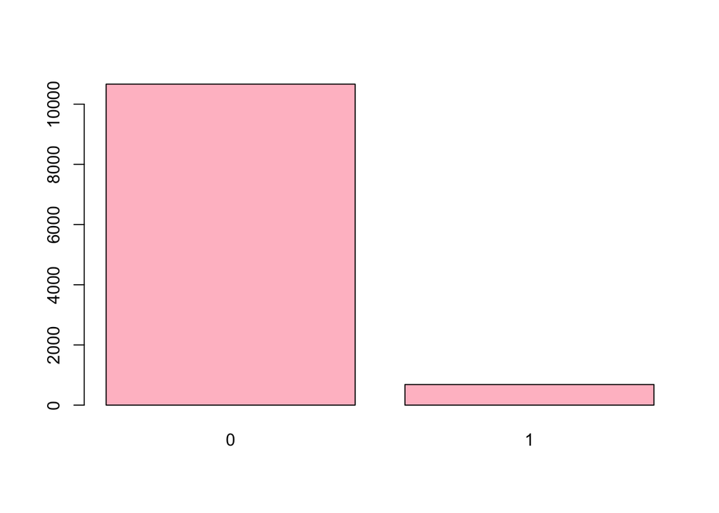

```r
barplot(table(train$TARGET),col="pink")
```

```r
#barplot(table(test$TARGET),col="red")?

prop.table(table(train$TARGET))
```

```
##
##          0          1
## 0.93965289 0.06034711
```

```r
#prop.table(table(test$TARGET))?

#unbalanced because it is skewed.
```

> With respect to the target, the data is unbalanced because it is skewed.

> Task 2: Relationship Between Target & Predictors

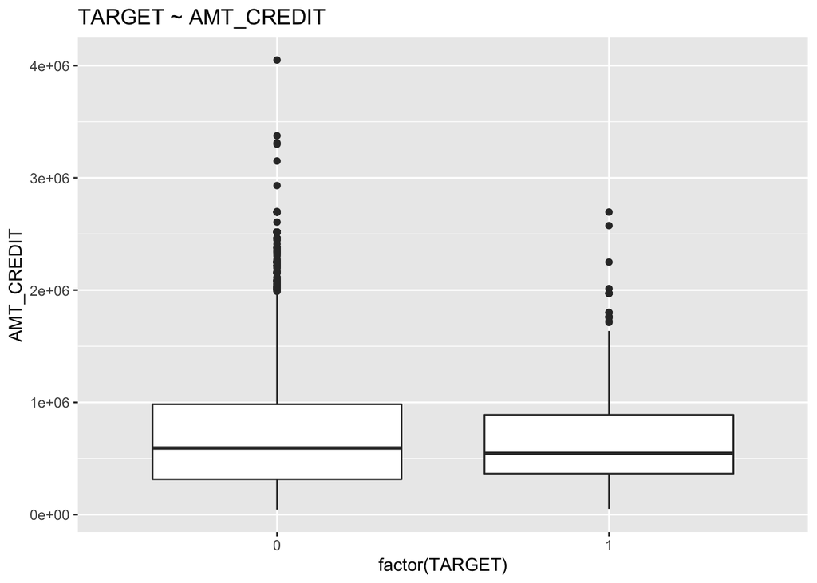

```r
ggplot(train, aes(x = factor(TARGET), y = AMT_CREDIT)) +
  geom_boxplot() +
  labs(title = "TARGET ~ AMT_CREDIT")
```

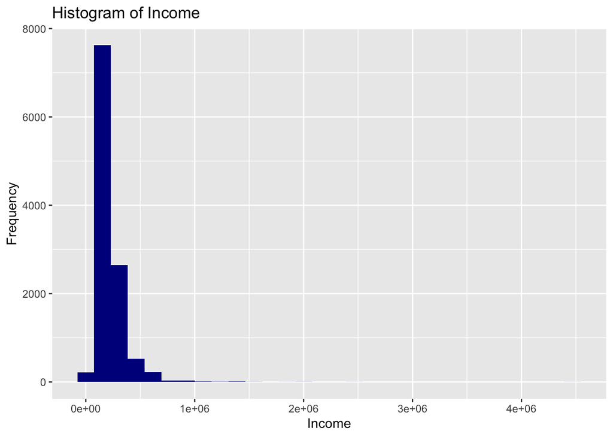

```r
ggplot(train,aes(x=AMT_INCOME_TOTAL))+
  geom_histogram(fill="darkblue") +
  xlab("Income") +
  ylab("Frequency") +
  ggtitle("Histogram of Income")
```